# DATA621_HW1

William Aiken

9/20/2022

## 1. DATA EXPLORATION

Due to the nunber of fields in this data, I broke the dataset into intuitive sections and explored each section individually.

```r
eval_df <- read.csv("https://raw.githubusercontent.com/catfoodlover/DATA621/main/HW1/moneyball-evaluation-data.csv")
train_df <- read.csv("https://raw.githubusercontent.com/catfoodlover/DATA621/main/HW1/moneyball-training-data.csv")
```

### Base Hits by Batter

- TARGET_WINS - Number of wins
- TEAM_BATTING_H - Base Hits by batters (1B,2B,3B,HR)
- TEAM_BATTING_2B - Doubles by batters (2B)
- TEAM_BATTING_3B - Triples by batters (3B)
- TEAM_BATTING_HR - Homeruns by batters (4B)

The means and medians are very similar for the base hits variables implying little skew to the distributions.

```r
train_df %>% select(c("TARGET_WINS", "TEAM_BATTING_H","TEAM_BATTING_2B","TEAM_BATTING_3B","TEAM_BATTING_HR")) %>% gtsummary::tbl_summary(statistic =list(c("TARGET_WINS", "TEAM_BATTING_H","TEAM_BATTING_2B","TEAM_BATTING_3B","TEAM_BATTING_HR") ~ "{mean} {median} {sd}"
))
```

| **Characteristic** | **N = 2,276**<sup>1</sup> |
| --- | --- |
| TARGET_WINS | 81 82 16 |
| TEAM_BATTING_H | 1,469 1,454 145 |
| TEAM_BATTING_2B | 241 238 47 |
| TEAM_BATTING_3B | 55 47 28 |
| TEAM_BATTING_HR | 100 102 61 |

<sup>*1*</sup> Mean Median SD

We see tight distributions except for all base hits by batters (TEAM_BATTING_H).

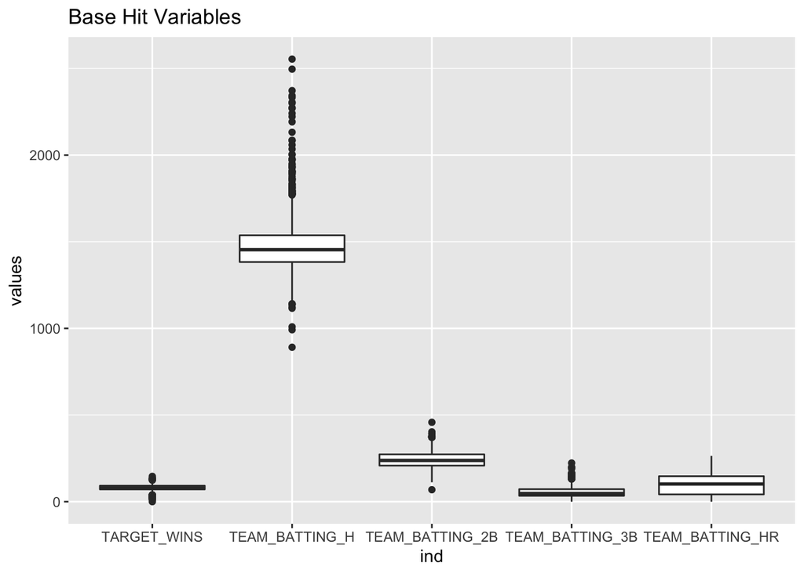

```r
temp <- train_df %>% select(c("TARGET_WINS", "TEAM_BATTING_H","TEAM_BATTING_2B","TEAM_BATTING_3B","TEAM_BATTING_HR"))

ggplot2::ggplot(stack(temp), aes(x = ind, y = values)) +
  geom_boxplot() + labs(title = "Base Hit Variables")
```

Interestingly, doubles and triples are correlated with base hits while home runs are not.

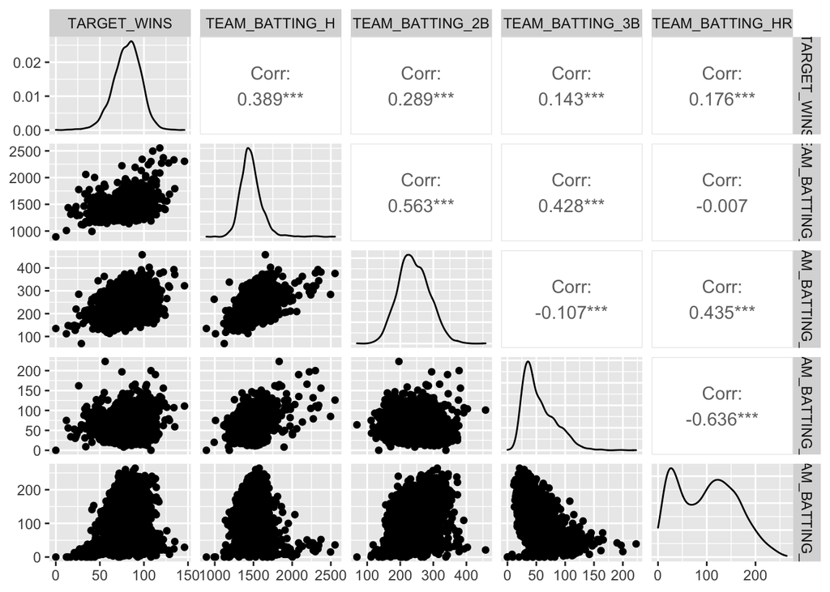

```r
train_df %>% select(c("TARGET_WINS", "TEAM_BATTING_H","TEAM_BATTING_2B","TEAM_BATTING_3B","TEAM_BATTING_HR")) %>% GGally::ggpairs()
```

### Batting

- TARGET_WINS - Number of wins
- TEAM_BATTING_BB - Walks by batters
- TEAM_BATTING_HBP - Batters hit by pitch (get a free base)
- TEAM_BATTING_SO - Strikeouts by batters
- TEAM_BASERUN_SB - Stolen bases
- TEAM_BASERUN_CS - Caught stealing

The measures of central tendency show us that most of these variable have slight skew to their distributions. Stolen bases has a large right skew to its distribution.

We are missing values for stikeouts, stolen bases and caught stealing.

```r
train_df %>% select(c("TEAM_BATTING_BB", "TEAM_BATTING_SO", "TEAM_BASERUN_SB", "TEAM_BASERUN_CS")) %>% gtsummary::tbl_summary(statistic =list(c("TEAM_BATTING_BB", "TEAM_BATTING_SO", "TEAM_BASERUN_SB", "TEAM_BASERUN_CS") ~ "{mean} {median} {sd}"
))
```

| **Characteristic** | **N = 2,276**<sup>1</sup> |
| --- | --- |
| TEAM_BATTING_BB | 502 512 123 |
| TEAM_BATTING_SO | 736 750 249 |
| Unknown | 102 |
| TEAM_BASERUN_SB | 125 101 88 |
| Unknown | 131 |
| TEAM_BASERUN_CS | 53 49 23 |
| Unknown | 772 |

<sup>*1*</sup> Mean Median SD

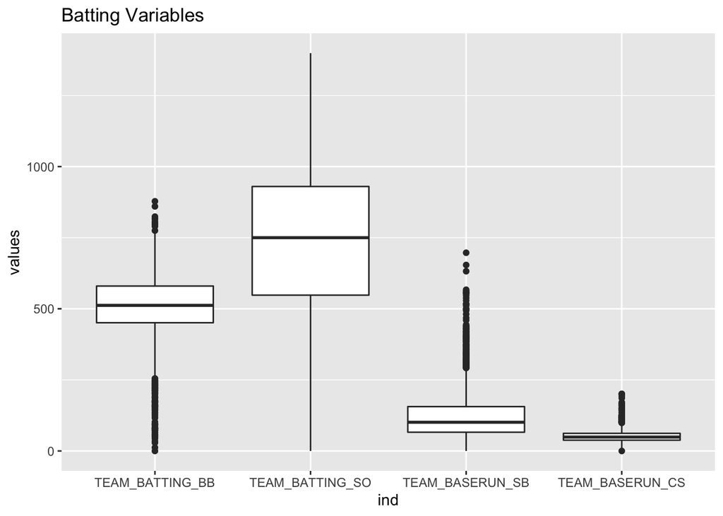

```r
temp <- train_df %>% select(c("TEAM_BATTING_BB", "TEAM_BATTING_SO", "TEAM_BASERUN_SB", "TEAM_BASERUN_CS"))

ggplot2::ggplot(stack(temp), aes(x = ind, y = values)) +
  geom_boxplot() + labs(title = "Batting Variables")
```

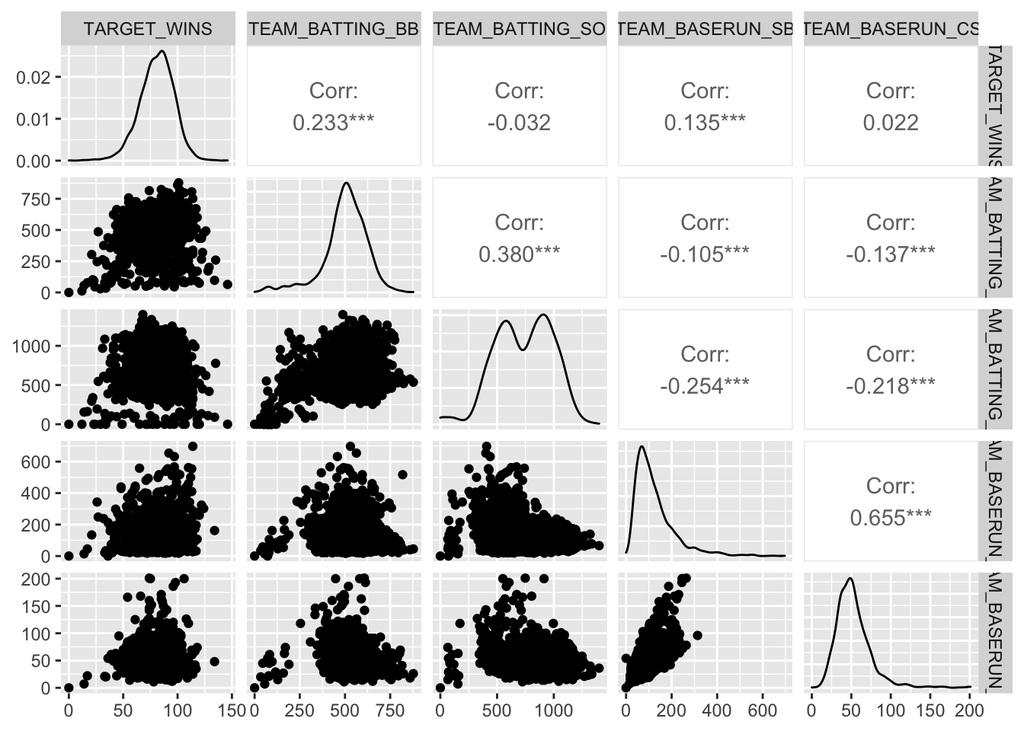

```r
train_df %>% select(c("TARGET_WINS", "TEAM_BATTING_BB", "TEAM_BATTING_SO", "TEAM_BASERUN_SB", "TEAM_BASERUN_CS")) %>% GGally::ggpairs()
```

### Fielding

- TARGET_WINS - Number of wins
- TEAM_FIELDING_E - Errors
- TEAM_FIELDING_DP - Double Plays

The Errors variable(TEAM_FIELDING_E) has an incredibly right skewed distribution. We are missing some Double Plays values.

```r
train_df %>% select(c("TEAM_FIELDING_E", "TEAM_FIELDING_DP")) %>% gtsummary::tbl_summary(statistic =list(c("TEAM_FIELDING_E", "TEAM_FIELDING_DP") ~ "{mean} {median} {sd}"
))
```

| **Characteristic** | **N = 2,276**<sup>1</sup> |
| --- | --- |
| TEAM_FIELDING_E | 246 159 228 |
| TEAM_FIELDING_DP | 146 149 26 |
| Unknown | 286 |

<sup>*1*</sup> Mean Median SD

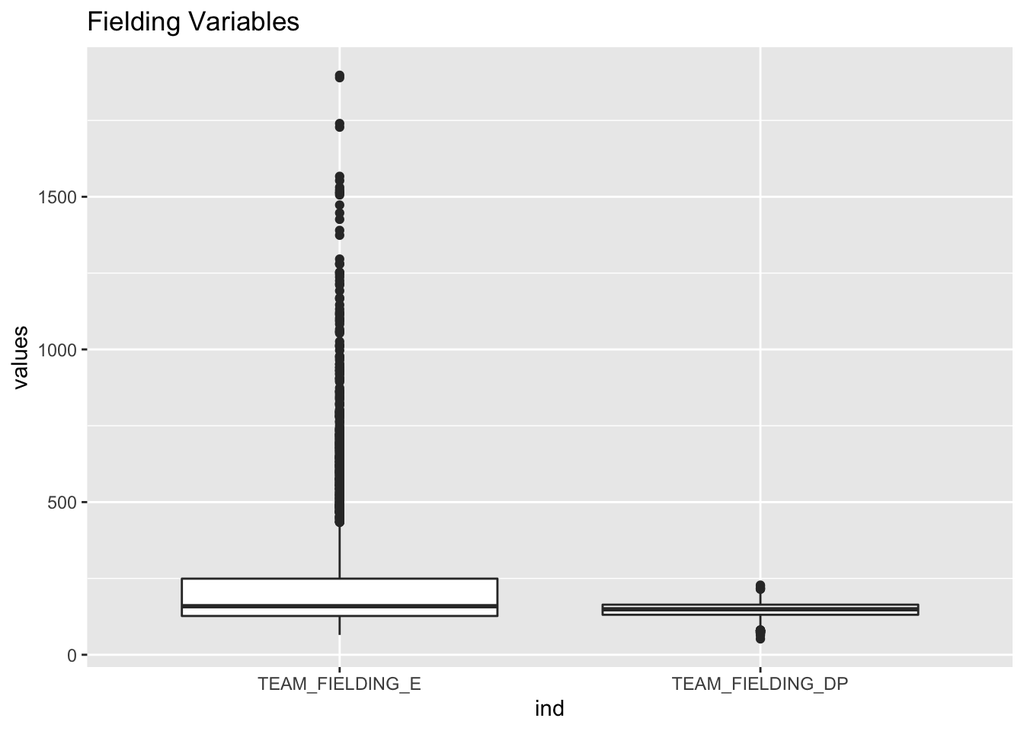

```r
temp <- train_df %>% select(c("TEAM_FIELDING_E", "TEAM_FIELDING_DP"))

ggplot2::ggplot(stack(temp), aes(x = ind, y = values)) +
  geom_boxplot() + labs(title = "Fielding Variables")
```

Both the Fielding variables are negatively correlated with Wins.

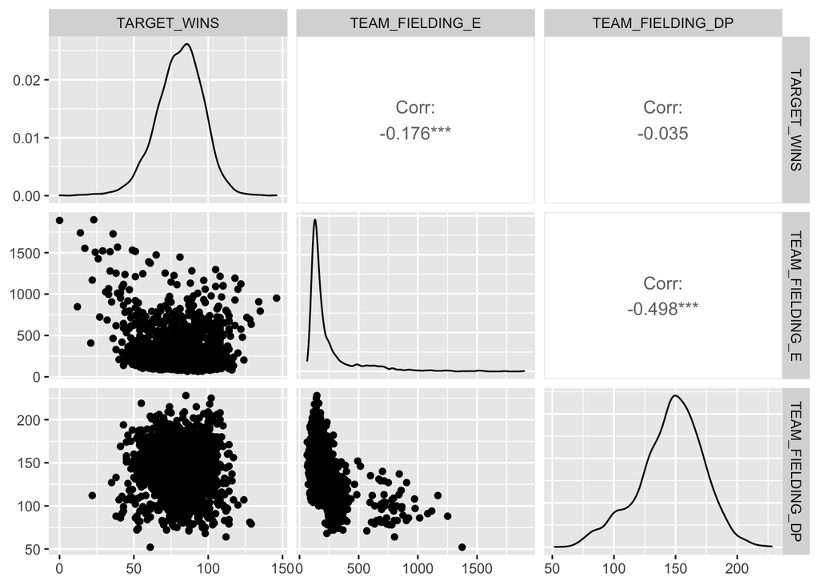

```r
train_df %>% select(c("TARGET_WINS", "TEAM_FIELDING_E", "TEAM_FIELDING_DP"))%>% GGally::ggpairs()
```

### Pitching

- TARGET_WINS - Number of wins
- TEAM_PITCHING_BB - Walks allowed
- TEAM_PITCHING_H - Hits allowed
- TEAM_PITCHING_HR - Homeruns allowed
- TEAM_PITCHING_SO - Strikeouts by pitchers

Hits allowed (TEAM_PITCHING_H) has a right skew and we are missing some Strikeouts by pitcher (TEAM_PITCHING_SO) values.

```r
train_df %>% select(c("TEAM_PITCHING_H", "TEAM_PITCHING_HR", "TEAM_PITCHING_BB", "TEAM_PITCHING_SO")) %>% gtsummary::tbl_summary(statistic =list(c("TEAM_PITCHING_H", "TEAM_PITCHING_HR", "TEAM_PITCHING_BB", "TEAM_PITCHING_SO") ~ "{mean} {median} {sd}"
))
```

| **Characteristic** | **N = 2,276**<sup>1</sup> |
| --- | --- |
| TEAM_PITCHING_H | 1,779 1,518 1,407 |
| TEAM_PITCHING_HR | 106 107 61 |
| TEAM_PITCHING_BB | 553 536 166 |
| TEAM_PITCHING_SO | 818 814 553 |
| Unknown | 102 |

<sup>*1*</sup> Mean Median SD

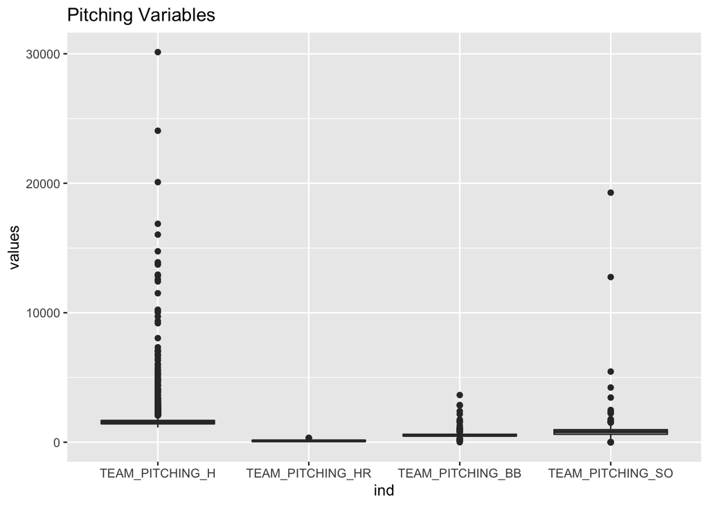

```r
temp <- train_df %>% select(c("TEAM_PITCHING_H", "TEAM_PITCHING_HR", "TEAM_PITCHING_BB", "TEAM_PITCHING_SO"))

ggplot2::ggplot(stack(temp), aes(x = ind, y = values)) +
  geom_boxplot() + labs(title = "Pitching Variables")
```

Hits allowed is negatively correlated with Winning.

Interestingly, Home runs allowed is positively correlated with Winning.

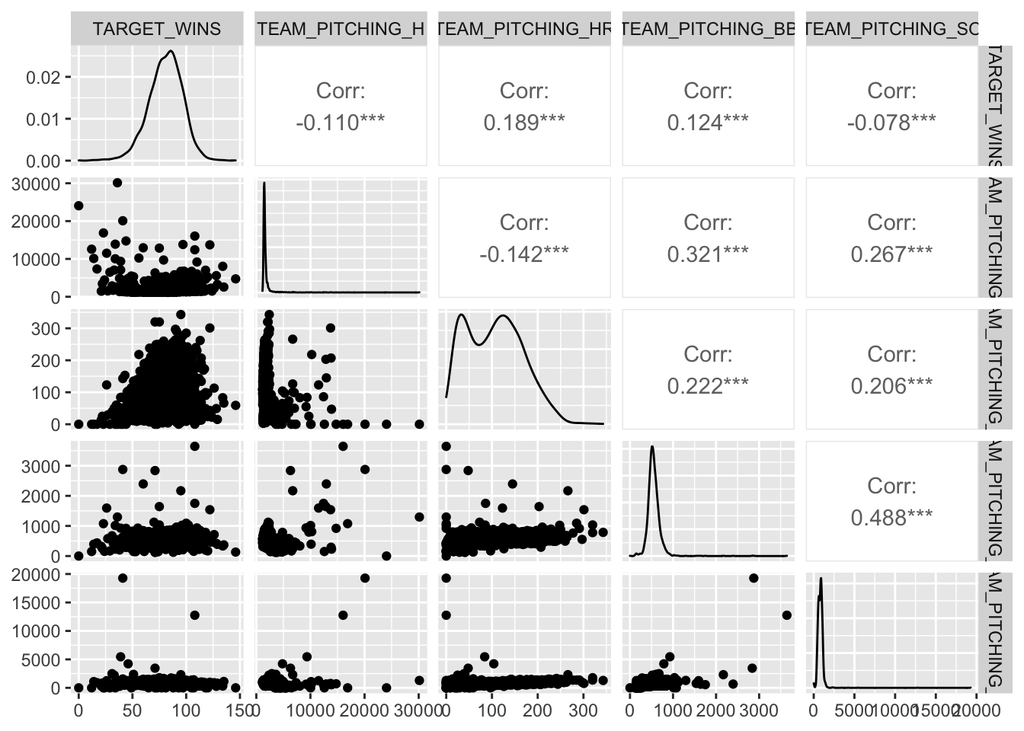

```r
train_df %>% select(c("TARGET_WINS","TEAM_PITCHING_H", "TEAM_PITCHING_HR", "TEAM_PITCHING_BB", "TEAM_PITCHING_SO"))%>% GGally::ggpairs()
```